# Incarceration Trends in the United States

Sean Kim

2022-11-21

## Abstract

One of the sharpest manifestations of racism in the United States is its prison system. To explore deeply into this, this research will use data analysis and visualization skills to expose patterns of inequality by using the incarceration data collected by the Vera Institute.

## Introduction

The incarceration trends in the United States exposes patterns of inequality. To show these patterns of inequality, I will do a research with data analysis and visualization skills on the incarceration data collected by the Vera Institute. One simple inequality the data show is that black people are much more likely to go to jail compared to white people.

The direct stakeholders that are impacted by this research are the people in the United States who are incarcerated. The indirect stakeholders could be people who work in the system. People who are affected by the incarcerated people such as their families could also be indirect stakeholders. The central values that I need to engage are equality and equity.

The questions that could be answered in this report are how the jail population changed over time and how it varies among states. Whether the incarceration trend differs according to the race or not could also be answered.

## Data Summary

One of the key variables is the jail population in the U.S. The values of the total of this variable in 1970 and 2018 are **1.60727^{5}** and **7.37126^{5}** respectively. The highest jail population was in **CA** and the lowest was in **CT, DE, RI**. Also, this variable increased by **5.76399^{5}** from 1970 to 2018. In 2018, the jail population of white people was **3.46062^{5}** while that of black people was **2.47547^{5}**. The ratio of this black population to white population is **0.7153256**. This value shows inequality in the prison system since the ratio of black people to white people is much higher in prison.

## Growth of the U.S. Prison Population

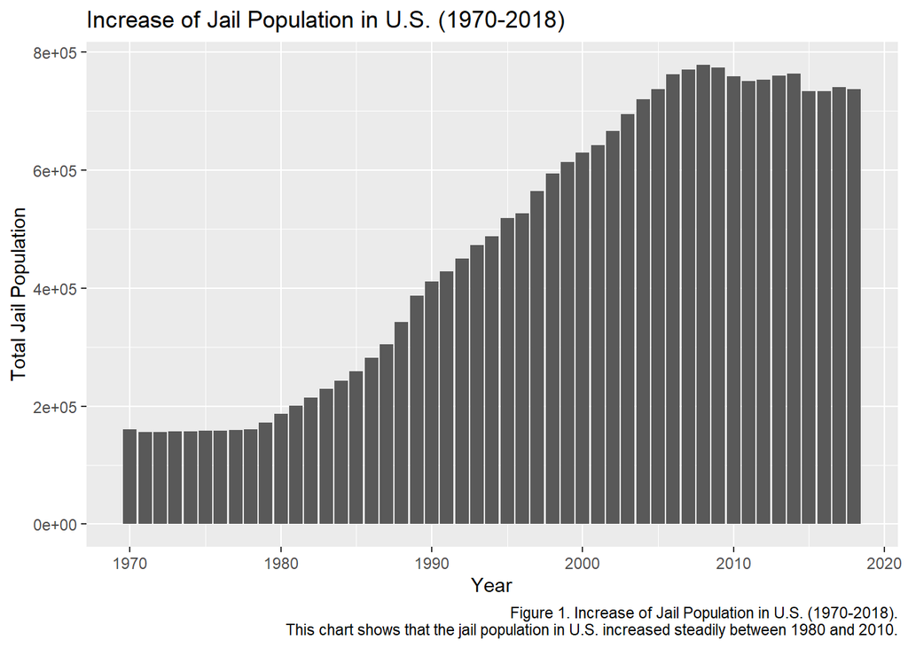

Question: How did jail population in the U.S. change over time? This chart shows how the jail population in the United States changed from 1970 to 2018. According to the chart, it stayed similar during the 1970’s. It then increased steadily until the 2008, and started to decrease after that.

## Growth of Prison Population by State

[figure not shown]

## General Population and Prison Population by Race

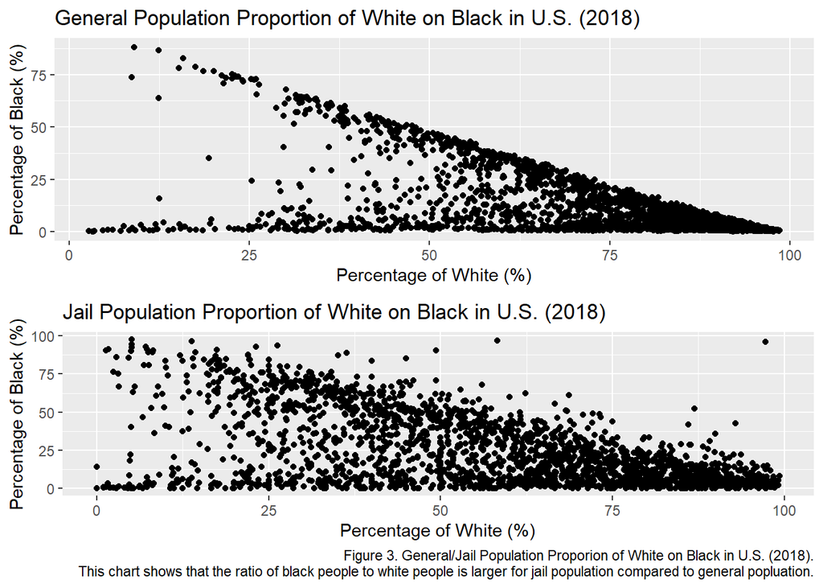

Question: How did jail population in the U.S. reveal potential patterns of inequality? This chart shows how the jail population in the United States reveals potential patterns of inequality between race. Each scatterplot visualizes general and jail population proportion of white people on black people in the United States in 2018. According to the chart, the ratio of black people to white people is larger for jail population compared to general population. This reveals that the current prison system might discriminate against black people.

## Map of Jail Population by State

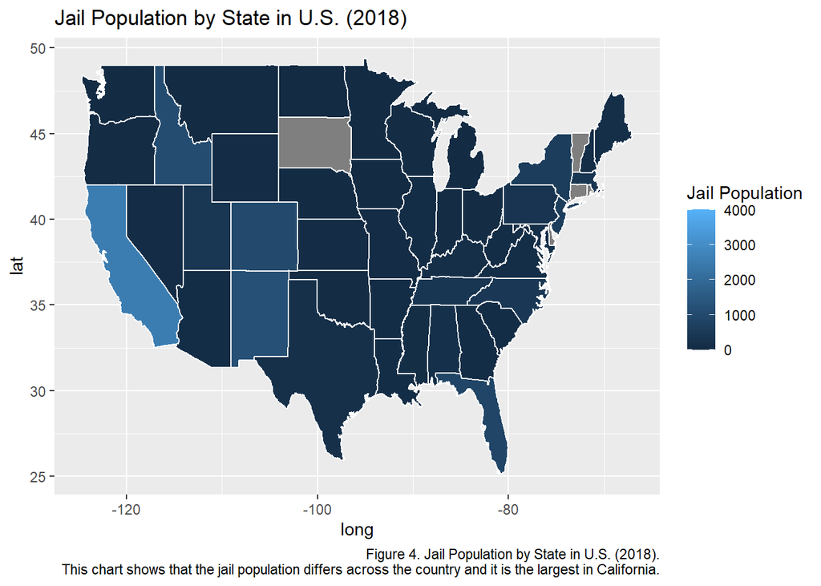